# Raport firmy

Grupa Wombat Grylls

2025-01-08

# Schemat

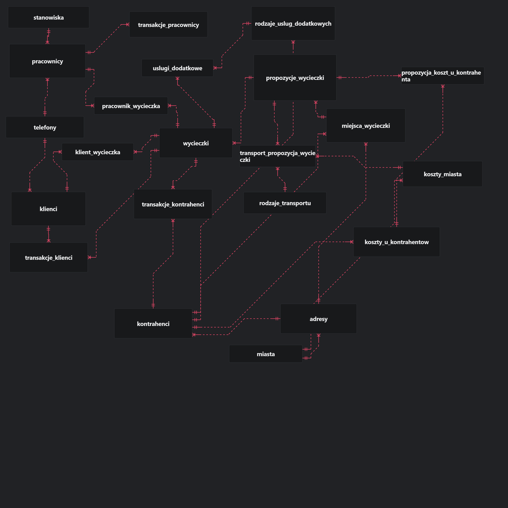

Schemat naszej bazy danych